# Coursera_MachineLearning_Assignment

Mark Long

November 17, 2018

```r
library(ggplot2)
library(caret)
```

# **Coursera - Machine Learning Assignment**

The goal of your project is to predict the manner in which they did the exercise. This is the “classe” variable in the training set. You may use any of the other variables to predict with. You should create a report describing how you built your model, how you used cross validation, what you think the expected out of sample error is, and why you made the choices you did. You will also use your prediction model to predict 20 different test cases.

# **Background**

Using devices such as Jawbone Up, Nike FuelBand, and Fitbit it is now possible to collect a large amount of data about personal activity relatively inexpensively. These type of devices are part of the quantified self movement - a group of enthusiasts who take measurements about themselves regularly to improve their health, to find patterns in their behavior, or because they are tech geeks. One thing that people regularly do is quantify how much of a particular activity they do, but they rarely quantify how well they do it. In this project, your goal will be to use data from accelerometers on the belt, forearm, arm, and dumbell of 6 participants. They were asked to perform barbell lifts correctly and incorrectly in 5 different ways. More information is available from the website here: http://web.archive.org/web/20161224072740/http:/groupware.les.inf.puc-rio.br/har (see the section on the Weight Lifting Exercise Dataset).

# **General Strategy**

To build the most accurate prediction for the provided testing data set, we will take the following steps: 1. Download the required data and perform some exploratory analyses to determine which variables to include in the final predictions (remove missing data, check for near zero variance, remove unrelated variables).

```
2. Subset our training set into two (training.set & testing.set, p = 0.7) In order to perform cross-validation.

3. Examine several machine learning models (decision tree, random forest, etc) to the training.set data.

4. Use our testing.set as a cross-validation set and predict the 'classe' variable given our model obtained from the training.set data.

5. Extract accuracy information regarding the cross-validation predictions.

6. Apply the most accurate model to the obtained testing data to predict 'classe' based on our predictor model.
```

# **Analyses: Data Processing**

- First, let’s import the data

```r
training <- download.file(url = "https://d396qusza40orc.cloudfront.net/predmachlearn/pml-training.csv",
                          destfile = "C:/Users/Mark/Desktop/Coursera/Data Science specialization/Practical Machine Learning_082418/pml_training.csv")


testing <- download.file(url = "https://d396qusza40orc.cloudfront.net/predmachlearn/pml-testing.csv",
                          destfile = "C:/Users/Mark/Desktop/Coursera/Data Science specialization/Practical Machine Learning_082418/pml_testing.csv")
```

```r
training <- read.csv("C:/Users/Mark/Desktop/Coursera/Data Science specialization/Practical Machine Learning_082418/pml_training.csv", row.names = 1)

testing <- read.csv("C:/Users/Mark/Desktop/Coursera/Data Science specialization/Practical Machine Learning_082418/pml_testing.csv", row.names = 1)
```

- Let’s check some basic characteristics of our data

```r
# Check the length of training/testing sets
dim(training); dim(testing)
```

```
## [1] 19622   159
```

```
## [1]  20 159
```

```r
# check distribution of the variable we want to predict
table(training$classe)
```

```
##
##    A    B    C    D    E
## 5580 3797 3422 3216 3607
```

- First let’s remove variables that lack sufficient data (has NA or empty values)

```r
training <- training[!sapply(training, function (x) any(is.na(x) | x == ""))]
testing <- testing[, colnames(testing) %in% colnames(training)]
dim(training); dim(testing)
```

```
## [1] 19622    59
```

```
## [1] 20 58
```

- So, our list of potential predictors has been reduced from 158 to 58
- We can also check for variables that have near zero variance and remove them:

```r
myDataNZV <- nearZeroVar(training, saveMetrics=TRUE)
myDataNZV
```

```
##                      freqRatio percentUnique zeroVar   nzv
## user_name             1.100679    0.03057792   FALSE FALSE
## raw_timestamp_part_1  1.000000    4.26562022   FALSE FALSE
## raw_timestamp_part_2  1.000000   85.53154622   FALSE FALSE
## cvtd_timestamp        1.000668    0.10192641   FALSE FALSE
## new_window           47.330049    0.01019264   FALSE  TRUE
## num_window            1.000000    4.37264295   FALSE FALSE
## roll_belt             1.101904    6.77810621   FALSE FALSE
## pitch_belt            1.036082    9.37722964   FALSE FALSE
## yaw_belt              1.058480    9.97349913   FALSE FALSE
## total_accel_belt      1.063160    0.14779329   FALSE FALSE
## gyros_belt_x          1.058651    0.71348486   FALSE FALSE
## gyros_belt_y          1.144000    0.35164611   FALSE FALSE
## gyros_belt_z          1.066214    0.86127816   FALSE FALSE
## accel_belt_x          1.055412    0.83579655   FALSE FALSE
## accel_belt_y          1.113725    0.72877383   FALSE FALSE
## accel_belt_z          1.078767    1.52379982   FALSE FALSE
## magnet_belt_x         1.090141    1.66649679   FALSE FALSE
## magnet_belt_y         1.099688    1.51870350   FALSE FALSE
## magnet_belt_z         1.006369    2.32901845   FALSE FALSE
## roll_arm             52.338462   13.52563449   FALSE FALSE
## pitch_arm            87.256410   15.73234125   FALSE FALSE
## yaw_arm              33.029126   14.65701763   FALSE FALSE
## total_accel_arm       1.024526    0.33635715   FALSE FALSE
## gyros_arm_x           1.015504    3.27693405   FALSE FALSE
## gyros_arm_y           1.454369    1.91621649   FALSE FALSE
## gyros_arm_z           1.110687    1.26388747   FALSE FALSE
## accel_arm_x           1.017341    3.95984099   FALSE FALSE
## accel_arm_y           1.140187    2.73672409   FALSE FALSE
## accel_arm_z           1.128000    4.03628580   FALSE FALSE
## magnet_arm_x          1.000000    6.82397309   FALSE FALSE
## magnet_arm_y          1.056818    4.44399144   FALSE FALSE
## magnet_arm_z          1.036364    6.44684538   FALSE FALSE
## roll_dumbbell         1.022388   84.20650290   FALSE FALSE
## pitch_dumbbell        2.277372   81.74498012   FALSE FALSE
## yaw_dumbbell          1.132231   83.48282540   FALSE FALSE
## total_accel_dumbbell  1.072634    0.21914178   FALSE FALSE
## gyros_dumbbell_x      1.003268    1.22821323   FALSE FALSE
## gyros_dumbbell_y      1.264957    1.41677709   FALSE FALSE
## gyros_dumbbell_z      1.060100    1.04984201   FALSE FALSE
## accel_dumbbell_x      1.018018    2.16593619   FALSE FALSE
## accel_dumbbell_y      1.053061    2.37488533   FALSE FALSE
## accel_dumbbell_z      1.133333    2.08949139   FALSE FALSE
## magnet_dumbbell_x     1.098266    5.74864948   FALSE FALSE
## magnet_dumbbell_y     1.197740    4.30129447   FALSE FALSE
## magnet_dumbbell_z     1.020833    3.44511263   FALSE FALSE
## roll_forearm         11.589286   11.08959331   FALSE FALSE
## pitch_forearm        65.983051   14.85577413   FALSE FALSE
## yaw_forearm          15.322835   10.14677403   FALSE FALSE
## total_accel_forearm   1.128928    0.35674243   FALSE FALSE
## gyros_forearm_x       1.059273    1.51870350   FALSE FALSE
## gyros_forearm_y       1.036554    3.77637346   FALSE FALSE
## gyros_forearm_z       1.122917    1.56457038   FALSE FALSE
## accel_forearm_x       1.126437    4.04647844   FALSE FALSE
## accel_forearm_y       1.059406    5.11160942   FALSE FALSE
## accel_forearm_z       1.006250    2.95586586   FALSE FALSE
## magnet_forearm_x      1.012346    7.76679238   FALSE FALSE
## magnet_forearm_y      1.246914    9.54031189   FALSE FALSE
## magnet_forearm_z      1.000000    8.57710733   FALSE FALSE
## classe                1.469581    0.02548160   FALSE FALSE
```

```r
# Remove near zero variance variables from training/testing sets
training <- training[, colnames(training) %in% rownames(myDataNZV)[myDataNZV$nzv == FALSE]]
testing <- testing[, colnames(testing) %in% rownames(myDataNZV)[myDataNZV$nzv == FALSE]]
```

- Let’s also remove individual name and date variables (and any other variables that are not muscle measurements) so that they do not interfere with model

```r
training <- training[, -c(1:5)]
testing <- testing[, -c(1:5)]
```

- Let’s visualize our predictors to try to get an idea of which might be useful in the model

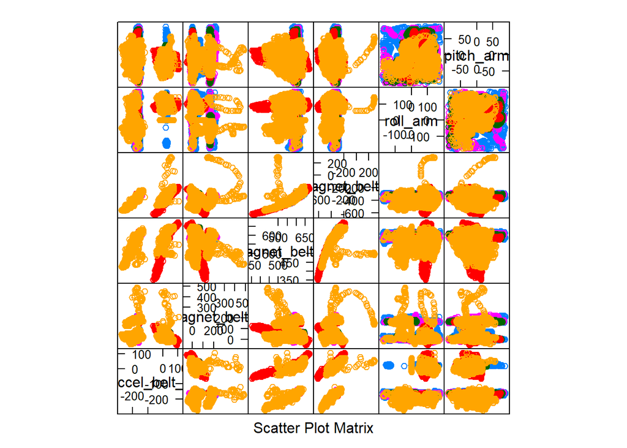

```r
featurePlot(x=training[, c(10:15)],
        y=training$classe,
        plot ="pairs")
```

```r
#
inTrain <- createDataPartition(y=training$classe, p=0.7, list=FALSE)
training.set <- training[inTrain, ]
testing.set <- training[-inTrain, ]

# Check sizes of each set
dim(training.set); dim(testing.set)
```

```
## [1] 13737    53
```

```
## [1] 5885   53
```

# **Analyses: Application of ML Models**

- Next, let’s build some models, starting by building a decision tree:

```r
# Train decision tree on training.set
modFit.DT <- train(classe ~ ., method = "rpart", data=training.set)
print(modFit.DT$finalModel)
```

```
## n= 13737
##
## node), split, n, loss, yval, (yprob)
##       * denotes terminal node
##
##  1) root 13737 9831 A (0.28 0.19 0.17 0.16 0.18)
##    2) roll_belt< 130.5 12572 8677 A (0.31 0.21 0.19 0.18 0.11)
##      4) pitch_forearm< -26.7 1225   59 A (0.95 0.048 0 0 0) *
##      5) pitch_forearm>=-26.7 11347 8618 A (0.24 0.23 0.21 0.2 0.12)
##       10) magnet_dumbbell_y< 439.5 9608 6936 A (0.28 0.18 0.24 0.19 0.11)
##         20) roll_forearm< 121.5 5900 3511 A (0.4 0.18 0.19 0.17 0.058) *
##         21) roll_forearm>=121.5 3708 2482 C (0.076 0.17 0.33 0.23 0.19) *
##       11) magnet_dumbbell_y>=439.5 1739  852 B (0.033 0.51 0.043 0.22 0.19) *
##    3) roll_belt>=130.5 1165   11 E (0.0094 0 0 0 0.99) *
```

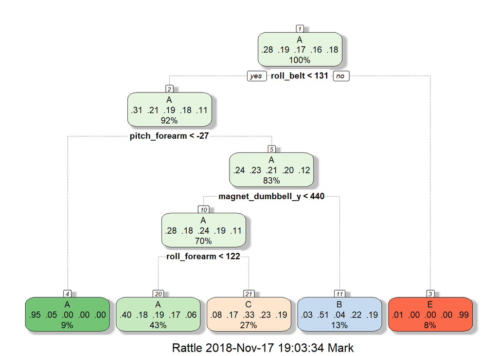

```r
# Plot decision tree (as dendrogram)
#plot(modFit.DT$finalModel, uniform=TRUE, main="Classification Tree")
#text(modFit.DT$finalModel, use.n=TRUE, all=TRUE, cex=0.8)
# Or, a better version of plot using rattle
library(rattle)
fancyRpartPlot(modFit.DT$finalModel)
```

```r
# Predict 'classe' variable in cross-validation set
pred.DT <- predict(modFit.DT, newdata=testing.set)

# Check predictions with confusion matrix output
confusionMatrix(pred.DT, testing.set$classe)
```

```
## Confusion Matrix and Statistics
##
##           Reference
## Prediction    A    B    C    D    E
##          A 1537  485  488  430  180
##          B   23  379   34  177  156
##          C  111  275  504  357  269
##          D    0    0    0    0    0
##          E    3    0    0    0  477
##
## Overall Statistics
##
##                Accuracy : 0.4923
##                  95% CI : (0.4794, 0.5051)
##     No Information Rate : 0.2845
##     P-Value [Acc > NIR] : < 2.2e-16
##
##                   Kappa : 0.3354
##  Mcnemar's Test P-Value : NA
##
## Statistics by Class:
##
##                      Class: A Class: B Class: C Class: D Class: E
## Sensitivity            0.9182   0.3327  0.49123   0.0000  0.44085
## Specificity            0.6241   0.9178  0.79173   1.0000  0.99938
## Pos Pred Value         0.4926   0.4928  0.33245      NaN  0.99375
## Neg Pred Value         0.9505   0.8514  0.88052   0.8362  0.88807
## Prevalence             0.2845   0.1935  0.17434   0.1638  0.18386
## Detection Rate         0.2612   0.0644  0.08564   0.0000  0.08105
## Detection Prevalence   0.5302   0.1307  0.25760   0.0000  0.08156
## Balanced Accuracy      0.7711   0.6253  0.64148   0.5000  0.72011
```

- Accuracy is not great. Seems to have a hard time predicting the ‘D’ class.
- Next, let’s apply a random forest model:

```r
library(randomForest)

# Train random forest on training.set
modFit.RF <- randomForest(classe ~. , data=training.set)
print(modFit.RF)
```

```
##
## Call:
##  randomForest(formula = classe ~ ., data = training.set)
##                Type of random forest: classification
##                      Number of trees: 500
## No. of variables tried at each split: 7
##
##         OOB estimate of  error rate: 0.53%
## Confusion matrix:
##      A    B    C    D    E  class.error
## A 3903    3    0    0    0 0.0007680492
## B   14 2636    8    0    0 0.0082768999
## C    0    9 2383    4    0 0.0054257095
## D    0    0   25 2226    1 0.0115452931
## E    0    0    2    7 2516 0.0035643564
```

```r
# Get a single tree
#getTree(modFit.RF, k=2)

# We can now predict 'classe' values in testing.set
pred.RF <- predict(modFit.RF, newdata=testing.set)

# Check predictions with confusion matrix output
confusionMatrix(pred.RF, testing.set$classe)
```

```
## Confusion Matrix and Statistics
##
##           Reference
## Prediction    A    B    C    D    E
##          A 1673    1    0    0    0
##          B    0 1138    7    0    0
##          C    0    0 1017   11    0
##          D    0    0    2  952    2
##          E    1    0    0    1 1080
##
## Overall Statistics
##
##                Accuracy : 0.9958
##                  95% CI : (0.9937, 0.9972)
##     No Information Rate : 0.2845
##     P-Value [Acc > NIR] : < 2.2e-16
##
##                   Kappa : 0.9946
##  Mcnemar's Test P-Value : NA
##
## Statistics by Class:
##
##                      Class: A Class: B Class: C Class: D Class: E
## Sensitivity            0.9994   0.9991   0.9912   0.9876   0.9982
## Specificity            0.9998   0.9985   0.9977   0.9992   0.9996
## Pos Pred Value         0.9994   0.9939   0.9893   0.9958   0.9982
## Neg Pred Value         0.9998   0.9998   0.9981   0.9976   0.9996
## Prevalence             0.2845   0.1935   0.1743   0.1638   0.1839
## Detection Rate         0.2843   0.1934   0.1728   0.1618   0.1835
## Detection Prevalence   0.2845   0.1946   0.1747   0.1624   0.1839
## Balanced Accuracy      0.9996   0.9988   0.9945   0.9934   0.9989
```

```r
#qplot(pred.DT, pred.RF, colour=classe, data=testing.set)
```

```r
# Fit a model that combined predictors
predDF <- data.frame(pred.DT, pred.RF, classe=testing.set$classe)
combModFit <- train(classe ~ ., method="gam", data=predDF)
combPred <- predict(combModFit, predDF)

# Check predictions with confusion matrix output
confusionMatrix(combPred, testing.set$classe)
```

```
## Confusion Matrix and Statistics
##
##           Reference
## Prediction    A    B    C    D    E
##          A 1673    1    0    0    0
##          B    1 1138 1026  964 1082
##          C    0    0    0    0    0
##          D    0    0    0    0    0
##          E    0    0    0    0    0
##
## Overall Statistics
##
##                Accuracy : 0.4777
##                  95% CI : (0.4648, 0.4905)
##     No Information Rate : 0.2845
##     P-Value [Acc > NIR] : < 2.2e-16
##
##                   Kappa : 0.3308
##  Mcnemar's Test P-Value : NA
##
## Statistics by Class:
##
##                      Class: A Class: B Class: C Class: D Class: E
## Sensitivity            0.9994   0.9991   0.0000   0.0000   0.0000
## Specificity            0.9998   0.3525   1.0000   1.0000   1.0000
## Pos Pred Value         0.9994   0.2702      NaN      NaN      NaN
## Neg Pred Value         0.9998   0.9994   0.8257   0.8362   0.8161
## Prevalence             0.2845   0.1935   0.1743   0.1638   0.1839
## Detection Rate         0.2843   0.1934   0.0000   0.0000   0.0000
## Detection Prevalence   0.2845   0.7155   0.0000   0.0000   0.0000
## Balanced Accuracy      0.9996   0.6758   0.5000   0.5000   0.5000
```

- This is actually not as good as the random forest alone, so let’s stick with that model to predict the testing set

```r
predFinal <- predict(modFit.RF, testing)
predFinal
```

```
##  1  2  3  4  5  6  7  8  9 10 11 12 13 14 15 16 17 18 19 20
##  B  A  B  A  A  E  D  B  A  A  B  C  B  A  E  E  A  B  B  B
## Levels: A B C D E
```